# **Milestone 1**

## **Data Description**

There are a total of 24,958 train and 2,600 test images (colored) that we have taken from microscopic images. These images are of the following categories:

**Parasitized:** The parasitized cells contain the Plasmodium parasite which causes malaria  
**Uninfected:** The uninfected cells are free of the Plasmodium parasites

## **Important Notes**

- This notebook can be considered a guide to refer to while solving the problem. The evaluation will be as per the Rubric shared for each Milestone. Unlike previous courses, it does not follow the pattern of the graded questions in different sections. This notebook would give you a direction on what steps need to be taken in order to get a viable solution to the problem. Please note that this is just one way of doing this. There can be other 'creative' ways to solve the problem and we urge you to feel free and explore them as an 'optional' exercise.
- In the notebook, there are markdowns cells called - Observations and Insights. It is a good practice to provide observations and extract insights from the outputs.
- The naming convention for different variables can vary. Please consider the code provided in this notebook as a sample code.
- All the outputs in the notebook are just for reference and can be different if you follow a different approach.
- There are sections called **Think About It** in the notebook that will help you get a better understanding of the reasoning behind a particular technique/step. Interested learners can take alternative approaches if they want to explore different techniques.

### **Mounting the Drive**

```python
# Mounting the drive
from google.colab import drive
drive.mount('/content/drive')
```

### **Loading libraries**

```python
# Importing libraries required to load the data
import zipfile

import os

from PIL import Image

import numpy as np

import pandas as pd

import matplotlib.pyplot as plt

import seaborn as sns

from sklearn.model_selection import train_test_split

from sklearn.preprocessing import MinMaxScaler

# To ignore warnings
import warnings

warnings.filterwarnings('ignore')

# Remove the limit from the number of displayed columns and rows. It helps to see the entire dataframe while printing it
pd.set_option("display.max_columns", None)

pd.set_option("display.max_rows", 200)
```

### **Let us load the data**

**Note:**

- You must download the dataset from the link provided on Olympus and upload the same on your Google drive before executing the code in the next cell.
- In case of any error, please make sure that the path of the file is correct as the path may be different for you.

```python
# Storing the path of the data file from the Google drive
path = '/content/drive/MyDrive/Capstone_Project/cell_images.zip'

# The data is provided as a zip file so we need to extract the files from the zip file
with zipfile.ZipFile(path, 'r') as zip_ref:

    zip_ref.extractall()
```

The extracted folder has different folders for train and test data which further contains the different sizes of images for parasitized and uninfected cells within the respective folder name.

The size of all images must be the same and should be converted to 4D arrays so that they can be used as an input for the convolutional neural network. Also, we need to create the labels for both types of images to be able to train and test the model.

Let's do the same for the training data first and then we will use the same code for the test data as well.

```python
# Storing the path of the extracted "train" folder
train_dir = '/content/cell_images/train'

# Size of image so that each image has the same size
SIZE = 64

# Empty list to store the training images after they are converted to NumPy arrays
train_images = []

# Empty list to store the training labels (0 - uninfected, 1 - parasitized)
train_labels = []
```

```python
# We will run the same code for "parasitized" as well as "uninfected" folders within the "train" folder
for folder_name in ['/parasitized/', '/uninfected/']:

    # Path of the folder
    images_path = os.listdir(train_dir + folder_name)

    for i, image_name in enumerate(images_path):

        try:

            # Opening each image using the path of that image
            image = Image.open(train_dir + folder_name + image_name)

            # Resizing each image to (64, 64)
            image = image.resize((SIZE, SIZE))

            # Converting images to arrays and appending that array to the empty list defined above
            train_images.append(np.array(image))

            # Creating labels for parasitized and uninfected images
            if folder_name == '/parasitized/':

                train_labels.append(1)

            else:

                train_labels.append(0)

        except Exception:

            pass

# Converting lists to arrays
train_images = np.array(train_images)

train_labels = np.array(train_labels)
```

```python
# Storing the path of the extracted "test" folder
test_dir = '/content/cell_images/test'

# Size of image so that each image has the same size (it must be same as the train image size)
SIZE = 64

# Empty list to store the testing images after they are converted to NumPy arrays
test_images = []

# Empty list to store the testing labels (0 - uninfected, 1 - parasitized)
test_labels = []
```

```python
# We will run the same code for "parasitized" as well as "uninfected" folders within the "test" folder
for folder_name in ['/parasitized/', '/uninfected/']:

    # Path of the folder
    images_path = os.listdir(test_dir + folder_name)

    for i, image_name in enumerate(images_path):

        try:
            # Opening each image using the path of that image
            image = Image.open(test_dir + folder_name + image_name)

            # Resizing each image to (64, 64)
            image = image.resize((SIZE, SIZE))

            # Converting images to arrays and appending that array to the empty list defined above
            test_images.append(np.array(image))

            # Creating labels for parasitized and uninfected images
            if folder_name == '/parasitized/':

                test_labels.append(1)

            else:

                test_labels.append(0)

        except Exception:

            pass

# Converting lists to arrays
test_images = np.array(test_images)

test_labels = np.array(test_labels)
```

### **Checking the shape of train and test images**

```python
# Shape of images
print("Shape of first train image:", train_images[0].shape)

print()

print("Shape of first test image:", test_images[0].shape)
```

```
Shape of first train image: (64, 64, 3)

Shape of first test image: (64, 64, 3)
```

### **Checking the shape of train and test labels**

```python
# Shape of labels
print("Shape of train labels:", train_labels.shape)

print()

print("Shape of test labels:", test_labels.shape)
```

```
Shape of train labels: (24958,)

Shape of test labels: (2600,)
```

#### **Observations and insights: The sizes of the images in both the train and test directory have been resized to have height and width of 64, with 3 channels of colour red, green, and blue. The shape of the labels signifies the total number of images in the train and test folders, confirming the data description above.**

### **Check the minimum and maximum range of pixel values for train and test images**

```python
# Try to use min and max function from numpy

print("Pixel range for train images:", np.min(train_images), "-", np.max(train_images))

print()

print("Pixel range for test images:", np.min(test_images), "-", np.max(test_images))
```

```
Pixel range for train images: 0 - 255

Pixel range for test images: 0 - 255
```

#### **Observations and insights: The pixels for both the train and test images range from 0 to 255.**

### **Count the number of values in both uninfected and parasitized**

```python
# Try to use value_counts to count the values

malaria_train = pd.Series(train_labels)
train_para = malaria_train.value_counts()[1]
train_uninf = malaria_train.value_counts()[0]
print("In train set")
print("Number of parasitized:", train_para)
print("Number of uninfected:",train_uninf, '\n')

malaria_test = pd.Series(test_labels)
test_para = malaria_test.value_counts()[1]
test_uninf = malaria_test.value_counts()[0]
print("In test set")
print("Number of parasitized:", test_para)
print("Number of uninfected:", test_uninf)
```

```
In train set
Number of parasitized: 12582
Number of uninfected: 12376

In test set
Number of parasitized: 1300
Number of uninfected: 1300
```

### **Normalize the images**

```python
# Try to normalize the train and test images by dividing it by 255 and convert them to float32 using astype function
train_images = (train_images/255).astype('float32')

test_images = (test_images/255).astype('float32')
```

#### **Observations and insights: The number of parasitized versus uninfected are fairly evenly distributed in the train set and perfectly split in the test set. The images were normalized by dividing by 255, the maximum number of pixels of the images.**

### **Plot to check if the data is balanced**

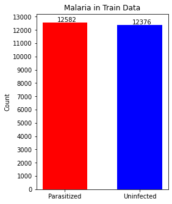

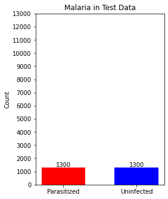

```python
# You are free to use bar plot or pie-plot or count plot, etc. to plot the labels of train and test data and check if they are balanced
fig = plt.figure()
ax = fig.add_axes([0,0,0.5,1])
count = [train_para, train_uninf]
infection = ['Parasitized', 'Uninfected']

x_pos= [0, 0.5]
plt.bar(x_pos,count, width=0.3, color=['r','b'])

plt.yticks(np.arange(0, 14000, 1000))
plt.text(x=-0.05, y=train_para +50, s = train_para)
plt.text(x=0.45, y=train_uninf +50, s = train_uninf)
plt.xticks(x_pos, infection)

ax.set_ylabel('Count')
ax.set_title('Malaria in Train Data')

plt.show()

print()

fig = plt.figure()
ax = fig.add_axes([0,0,0.5,1])
count = [test_para, test_uninf]
infection = ['Parasitized', 'Uninfected']

x_pos= [0, 0.5]
plt.bar(x_pos,count, width=0.3, color=['r','b'])

plt.yticks(np.arange(0, 14000, 1000))
plt.text(x=-0.05, y=test_para +50, s = test_para)
plt.text(x=0.45, y=test_uninf +50, s = test_uninf)
plt.xticks(x_pos, infection)

ax.set_ylabel('Count')
ax.set_title('Malaria in Test Data')

plt.show()
```

#### **Observations and insights: Here we can clearly see that there are a fairly equal number of parasitized and uninfected images in the train and test data sets. The training set is much larger than the test, allowing the model to utilize as much data as possible to find meaningful patterns in detection of malaria.**

### **Data Exploration**

Let's visualize the images from the train data

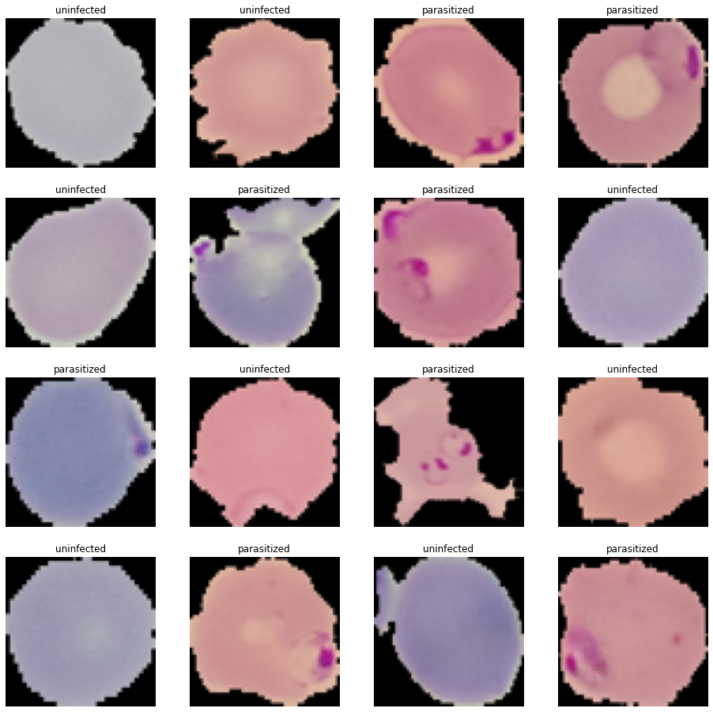

```python
# This code will help you in visualizing both the parasitized and uninfected images
np.random.seed(42)

plt.figure(1, figsize = (16 , 16))

for n in range(1, 17):

    plt.subplot(4, 4, n)

    index = int(np.random.randint(0, train_images.shape[0], 1))

    if train_labels[index] == 1:

        plt.title('parasitized')

    else:
        plt.title('uninfected')

    plt.imshow(train_images[index])

    plt.axis('off')
```

#### **Observations and insights: We can see that the parasitized images have small magenta spots indicating the damage on the red blood cells. The parasitized cells tend to be light pink in colour and the uninfected tend to be lavender, however this is not necessary. Most of the cells have a round perimeter but again is not necessary.**

### **Similarly visualize the images with subplot(6, 6) and figsize = (12, 12)**

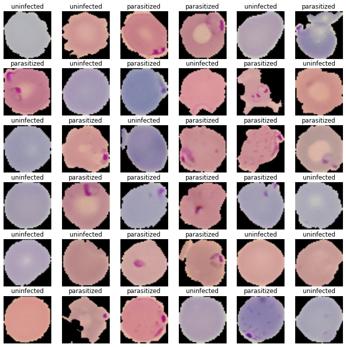

```python
# Hint: Have a keen look into the number of iterations that the for loop should iterate

np.random.seed(42)

plt.figure(1, figsize = (12 , 12))

for n in range(1, 37):

    plt.subplot(6, 6, n)

    index = int(np.random.randint(0, train_images.shape[0], 1))

    if train_labels[index] == 1:

        plt.title('parasitized')

    else:
        plt.title('uninfected')

    plt.imshow(train_images[index])

    plt.axis('off')
```

#### **Observations and insights: We can see that our observations regarding the magenta spots, lavender uninfected, light pink parasitized, and overall round cells still hold for these 36 images.**

### **Plotting the mean images for parasitized and uninfected**

```python
# Function to find the mean
def find_mean_img(full_mat, title):

    # Calculate the average
    mean_img = np.mean(full_mat, axis = 0)[0]

    # Reshape it back to a matrix
    plt.imshow(mean_img)

    plt.title(f'Average {title}')

    plt.axis('off')

    plt.show()

    return mean_img
```

**Mean image for parasitized**

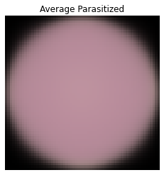

```python
# If the label = 1 then the image is parasitised and if the label = 0 then the image is uninfected
parasitized_data = []  # Create a list to store the parasitized data

for img, label in zip(train_images, train_labels):

        if label == 1:

              parasitized_data.append([img])

parasitized_mean = find_mean_img(np.array(parasitized_data), 'Parasitized')   # find the mean
```

**Mean image for uninfected**

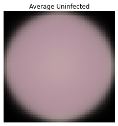

```python
# Similarly write the code to find the mean image of uninfected
# If the label = 1 then the image is parasitised and if the label = 0 then the image is uninfected
uninfected_data = []  # Create a list to store the uninfected data

for img, label in zip(train_images, train_labels):

        if label == 0:

              uninfected_data.append([img])

uninfected_mean = find_mean_img(np.array(uninfected_data), 'Uninfected')   # find the mean
```

### **Converting RGB to HSV of Images using OpenCV**

### **Converting the train data**

```python
import cv2

gfx=[]   # to hold the HSV image array

for i in np.arange(0, 100, 1):

  a = cv2.cvtColor(train_images[i], cv2.COLOR_BGR2HSV)

  gfx.append(a)

gfx = np.array(gfx)
```

[output not shown]

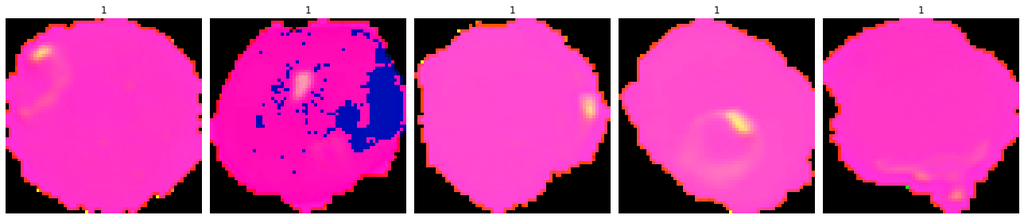

```python
viewimage = np.random.randint(1, 100, 5)

fig, ax = plt.subplots(1, 5, figsize = (18, 18))

for t, i in zip(range(5), viewimage):

  Title = train_labels[i]

  ax[t].set_title(Title)

  ax[t].imshow(gfx[i])

  ax[t].set_axis_off()

  fig.tight_layout()
```

[output not shown]

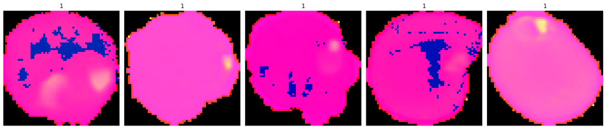

```python
# Similarly you can visualize for the images in the test data
viewimage = np.random.randint(1, 100, 5)

fig, ax = plt.subplots(1, 5, figsize = (18, 18))

for t, i in zip(range(5), viewimage):

  Title = test_labels[i]

  ax[t].set_title(Title)

  ax[t].imshow(gfx[i])

  ax[t].set_axis_off()

  fig.tight_layout()
```

#### **Observations and insights: By applying the hue saturation the parasitized spots are more easily visible in bright yellow.**

### **Processing Images using Gaussian Blurring**

### **Gaussian Blurring on train data**

```python
gbx = []  # To hold the blurred images

for i in np.arange(0, 100, 1):

  b = cv2.GaussianBlur(train_images[i], (5, 5), 0)

  gbx.append(b)

gbx = np.array(gbx)
```

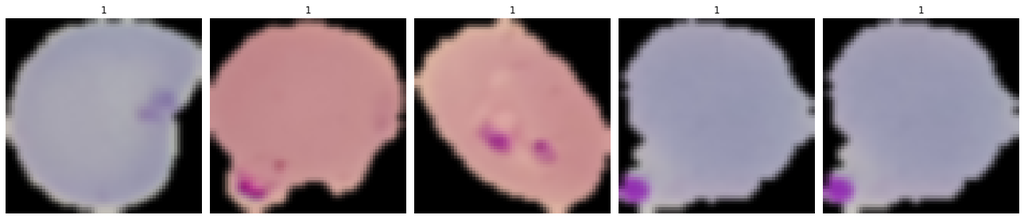

```python
viewimage = np.random.randint(1, 100, 5)

fig, ax = plt.subplots(1, 5, figsize = (18, 18))

for t, i in zip(range(5), viewimage):

  Title = train_labels[i]

  ax[t].set_title(Title)

  ax[t].imshow(gbx[i])

  ax[t].set_axis_off()

  fig.tight_layout()
```

### **Gaussian Blurring on test data**

```python
# Similarly you can apply Gaussian blurring for the images in the test data
gbt = []  # To hold the blurred images

for i in np.arange(0, 100, 1):

  b = cv2.GaussianBlur(test_images[i], (5, 5), 0)

  gbt.append(b)

gbt = np.array(gbt)
```

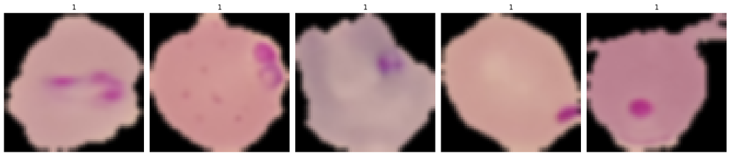

```python
viewimage = np.random.randint(1, 100, 5)

fig, ax = plt.subplots(1, 5, figsize = (18, 18))

for t, i in zip(range(5), viewimage):

  Title = test_labels[i]

  ax[t].set_title(Title)

  ax[t].imshow(gbt[i])

  ax[t].set_axis_off()

  fig.tight_layout()
```

#### **Observations and insights: Gaussian blur effectively blurs the whole image making it easier to identify by the different colours rather than the shape.**

**Think About It:** Would blurring help us for this problem statement in any way? What else can we try? Blurring does not necessarily help us solve this problem because of the fact that the colours used for recognizing, magenta, light pink and lavender, all belong to the same colour family and thus blurring can lose the key spot characteristics that we are trying to find. Rather HSV provides a sharper colour contrast to the various key identifiers in the image making it a better pre-processing filter.

## **Proposed approach**

**Potential techniques:** What different techniques should be explored?

Potential techniques that can be explored are artificial neural networks (ANN) and convolutional neural networks (CNN). ANN set up layers of nodes to mimic the neurons processing information in our brains. CNN is specifically designed to process image data and includes filtering layers to manage tensors. Varying the layers and their parameters can optimize the model to be the most accurate.

**Overall solution design:** What is the potential solution design?  
Solution design will consist of varying layers to optimize classification such as dense layers with ReLU activation, categorical cross entropy and Adam optimization. Additionally the number of epochs will vary to accommodate the number of nodes and layers. For CNN, we will also use leakyReLU, batch normalization and dropout to avoid over specificity.

**Measures of success:** What are the key measures of success to compare different techniques?  
Precision, recall, and f1-score to characterize the accuracy of the parasitized and uninfected cells. Confusion matrix and heat map to display the relationship between prediction of the model and actual classification.

# **Milestone 2**

### **Mounting the Drive**

```python
# Mounting the drive
from google.colab import drive

drive.mount('/content/drive')
```

### **Loading libraries**

```python
# Importing libraries required to load the data
import zipfile

import os

from PIL import Image

import numpy as np

import pandas as pd

import matplotlib.pyplot as plt

import seaborn as sns

from sklearn.model_selection import train_test_split

from sklearn.preprocessing import MinMaxScaler


import tensorflow as tf

from tensorflow.keras import optimizers

from tensorflow.keras.utils import to_categorical


# To ignore warnings
import warnings

warnings.filterwarnings('ignore')

# Remove the limit from the number of displayed columns and rows. It helps to see the entire dataframe while printing it
pd.set_option("display.max_columns", None)

pd.set_option("display.max_rows", 200)
```

### **Let us load the data**

**Note:**

- You must download the dataset from the link provided on Olympus and upload the same on your Google drive before executing the code in the next cell.
- In case of any error, please make sure that the path of the file is correct as the path may be different for you.

```python
# Storing the path of the data file from the Google drive
path = '/content/drive/MyDrive/Capstone_Project/cell_images.zip'

# The data is provided as a zip file so we need to extract the files from the zip file
with zipfile.ZipFile(path, 'r') as zip_ref:

    zip_ref.extractall()
```

The files have been extracted to the local session of Google Colab. The extracted folder would have the following structure:

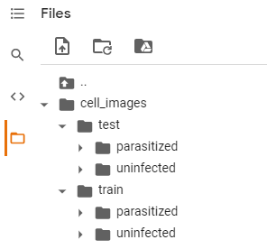

The extracted folder has different folders for train and test data which further contains the different sizes of images for parasitized and uninfected cells within the respective folder name.

The size of all images must be the same and should be converted to 4D arrays so that they can be used as an input for the convolutional neural network. Also, we need to create the labels for both types of images to be able to train and test the model.

Let's do the same for the training data first and then we will use the same code for the test data as well.

```python
# Storing the path of the extracted "train" folder
train_dir = '/content/cell_images/train'

# Size of image so that each image has the same size
SIZE = 64

# Empty list to store the training images after they are converted to NumPy arrays
train_images = []

# Empty list to store the training labels (0 - uninfected, 1 - parasitized)
train_labels = []
```

```python
# We will run the same code for "parasitized" as well as "uninfected" folders within the "train" folder
for folder_name in ['/parasitized/', '/uninfected/']:

    # Path of the folder
    images_path = os.listdir(train_dir + folder_name)

    for i, image_name in enumerate(images_path):

        try:

            # Opening each image using the path of that image
            image = Image.open(train_dir + folder_name + image_name)

            # Resizing each image to (64, 64)
            image = image.resize((SIZE, SIZE))

            # Converting images to arrays and appending that array to the empty list defined above
            train_images.append(np.array(image))

            # Creating labels for parasitized and uninfected images
            if folder_name == '/parasitized/':

                train_labels.append(1)

            else:

                train_labels.append(0)

        except Exception:

            pass

# Converting lists to arrays
train_images = np.array(train_images)

train_labels = np.array(train_labels)
```

```python
# Storing the path of the extracted "test" folder
test_dir = '/content/cell_images/test'

# Size of image so that each image has the same size (it must be same as the train image size)
SIZE = 64

# Empty list to store the testing images after they are converted to NumPy arrays
test_images = []

# Empty list to store the testing labels (0 - uninfected, 1 - parasitized)
test_labels = []
```

```python
# We will run the same code for "parasitized" as well as "uninfected" folders within the "test" folder
for folder_name in ['/parasitized/', '/uninfected/']:

    # Path of the folder
    images_path = os.listdir(test_dir + folder_name)

    for i, image_name in enumerate(images_path):

        try:
            # Opening each image using the path of that image
            image = Image.open(test_dir + folder_name + image_name)

            # Resizing each image to (64, 64)
            image = image.resize((SIZE, SIZE))

            # Converting images to arrays and appending that array to the empty list defined above
            test_images.append(np.array(image))

            # Creating labels for parasitized and uninfected images
            if folder_name == '/parasitized/':

                test_labels.append(1)

            else:

                test_labels.append(0)

        except Exception:

            pass

# Converting lists to arrays
test_images = np.array(test_images)

test_labels = np.array(test_labels)
```

### **Normalize the images**

```python
# Try to normalize the train and test images by dividing it by 255 and convert them to float32 using astype function
train_images = (train_images/255).astype('float32')

test_images = (test_images/255).astype('float32')
```

As we have done our preprocessing required and performed some EDA to gain some insights in our Milestone-1 so now we will try to build our model and try evaluating its performance.

### **One Hot Encoding on the train and test labels**

```python
# Encoding Train Labels

train_labels = to_categorical(train_labels, 2)

# Similarly let us try to encode test labels
test_labels = to_categorical(test_labels, 2)
```

### **Base Model**

**Note:** The Base Model has been fully built and evaluated with all outputs shown to give an idea about the process of the creation and evaluation of the performance of a CNN architecture. A similar process can be followed in iterating to build better-performing CNN architectures.

### **Importing the required libraries for building and training our Model**

```python
# Clearing backend
from tensorflow.keras import backend

from tensorflow.keras.utils import to_categorical

from tensorflow.keras.models import Sequential

from tensorflow.keras.layers import Conv2D, MaxPooling2D, Dense, Flatten, Dropout

from tensorflow.keras.callbacks import EarlyStopping, ModelCheckpoint

from random import shuffle

backend.clear_session()

# Fixing the seed for random number generators so that we can ensure we receive the same output everytime
np.random.seed(42)

import random

random.seed(42)

tf.random.set_seed(42)
```

### **Building the model**

```python
# Creating sequential model
model = Sequential()

model.add(Conv2D(filters = 32, kernel_size = 2, padding = "same", activation = "relu", input_shape = (64, 64, 3))) #first convolutional layer

model.add(MaxPooling2D(pool_size = 2))

model.add(Dropout(0.2))

model.add(Conv2D(filters = 32, kernel_size = 2, padding = "same", activation = "relu")) #second convolutional layer

model.add(MaxPooling2D(pool_size = 2))

model.add(Dropout(0.2))

model.add(Conv2D(filters = 32, kernel_size = 2, padding = "same", activation = "relu")) #third convolutional layer

model.add(MaxPooling2D(pool_size = 2))

model.add(Dropout(0.2))

model.add(Flatten())

model.add(Dense(512, activation = "relu"))

model.add(Dropout(0.4))

model.add(Dense(2, activation = "softmax")) # 2 represents output layer neurons

model.summary()
```

```
Model: "sequential"
_________________________________________________________________
 Layer (type)                Output Shape              Param #
=================================================================
 conv2d (Conv2D)             (None, 64, 64, 32)        416

 max_pooling2d (MaxPooling2D  (None, 32, 32, 32)       0
 )

 dropout (Dropout)           (None, 32, 32, 32)        0

 conv2d_1 (Conv2D)           (None, 32, 32, 32)        4128

 max_pooling2d_1 (MaxPooling  (None, 16, 16, 32)       0
 2D)

 dropout_1 (Dropout)         (None, 16, 16, 32)        0

 conv2d_2 (Conv2D)           (None, 16, 16, 32)        4128

 max_pooling2d_2 (MaxPooling  (None, 8, 8, 32)         0
 2D)

 dropout_2 (Dropout)         (None, 8, 8, 32)          0

 flatten (Flatten)           (None, 2048)              0

 dense (Dense)               (None, 512)               1049088

 dropout_3 (Dropout)         (None, 512)               0

 dense_1 (Dense)             (None, 2)                 1026

=================================================================
Total params: 1,058,786
Trainable params: 1,058,786
Non-trainable params: 0
_________________________________________________________________
```

### **Compiling the model**

```python
model.compile(loss = 'binary_crossentropy', optimizer = 'adam', metrics = ['accuracy'])
```

**Using Callbacks**

```python
callbacks = [EarlyStopping(monitor = 'val_loss', patience = 2),
             ModelCheckpoint('.mdl_wts.hdf5', monitor = 'val_loss', save_best_only = True)]
```

**Fit and train our Model**

```python
# Fit the model with min batch size as 32 can tune batch size to some factor of 2^power ]
history = model.fit(train_images, train_labels, batch_size = 32, callbacks = callbacks, validation_split = 0.2, epochs = 20, verbose = 1)
```

### **Evaluating the model on test data**

```python
accuracy = model.evaluate(test_images, test_labels, verbose = 1)
print('\n', 'Test_Accuracy:-', accuracy[1])
```

```
 Test_Accuracy:- 0.9788461327552795
```

**Plotting the confusion matrix**

```
              precision    recall  f1-score   support

           0       0.98      0.97      0.98      1300
           1       0.97      0.98      0.98      1300

    accuracy                           0.98      2600
   macro avg       0.98      0.98      0.98      2600
weighted avg       0.98      0.98      0.98      2600
```

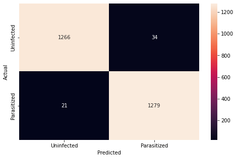

```python
from sklearn.metrics import classification_report

from sklearn.metrics import confusion_matrix

pred = model.predict(test_images)

pred = np.argmax(pred, axis = 1)

y_true = np.argmax(test_labels, axis = 1)

# Printing the classification report

class_rep = classification_report(y_true, pred)

print(class_rep)

class_rep = classification_report(y_true, pred, output_dict=True)


# Plotting the heatmap using confusion matrix
cm = confusion_matrix(y_true, pred)

plt.figure(figsize = (8, 5))

sns.heatmap(cm, annot = True,  fmt = '.0f', xticklabels = ['Uninfected', 'Parasitized'], yticklabels = ['Uninfected', 'Parasitized'])

plt.ylabel('Actual')

plt.xlabel('Predicted')

plt.show()
```

**Plotting the train and validation curves**

```python
# Function to plot train and validation accuracy
def plot_accuracy(history):

    N = len(history.history["accuracy"])

    plt.figure(figsize = (7, 7))

    plt.plot(np.arange(0, N), history.history["accuracy"], label = "train_accuracy", ls = '--')

    plt.plot(np.arange(0, N), history.history["val_accuracy"], label = "val_accuracy", ls = '--')

    plt.title("Accuracy vs Epoch")

    plt.xlabel("Epochs")

    plt.ylabel("Accuracy")

    plt.legend(loc="bottom right")
```

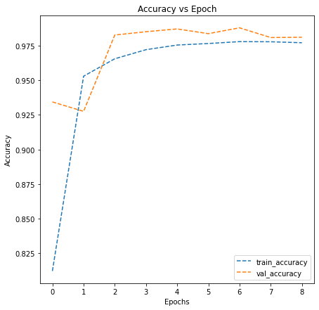

```python
plot_accuracy(history)
```

- Here we can clearly observe that the training and valiation accuracy are increasing
- And we can also notice that validation accuracy is slightly higher than the train accuracy

So now let's try to build another model with few more add on layers and try to check if we can try to improve the model. Therefore try to build a model by adding few layers if required and altering the activation functions.

### **Model 1**

#### **Trying to improve the performance of our model by adding new layers**

```python
backend.clear_session() # Clearing the backend for new model
```

### **Building the Model**

```python
# Creating sequential model
model1 = Sequential()

model1.add(Conv2D(filters = 32, kernel_size = 2, padding = "same", activation = "relu", input_shape = (64, 64, 3))) #first convolutional layer

model1.add(MaxPooling2D(pool_size = 2))

model1.add(Dropout(0.2))

model1.add(Conv2D(filters = 32, kernel_size = 2, padding = "same", activation = "relu")) #second convolutional layer

model1.add(MaxPooling2D(pool_size = 2))

model1.add(Dropout(0.2))

model1.add(Conv2D(filters = 32, kernel_size = 2, padding = "same", activation = "relu")) #third convolutional layer

model1.add(MaxPooling2D(pool_size = 2))

model1.add(Dropout(0.2))

model1.add(Conv2D(filters = 32, kernel_size = 2, padding = "same", activation = "relu")) #fourth convolutional layer

model1.add(MaxPooling2D(pool_size = 2))

model1.add(Dropout(0.2))

model1.add(Conv2D(filters = 32, kernel_size = 2, padding = "same", activation = "relu")) #fifth convolutional layer

model1.add(MaxPooling2D(pool_size = 2))

model1.add(Dropout(0.2))

model1.add(Flatten())

model1.add(Dense(512, activation = "relu"))

model1.add(Dropout(0.4))

model1.add(Dense(2, activation = "softmax")) # 2 represents output layer neurons

model1.summary()
```

```
Model: "sequential"
_________________________________________________________________
 Layer (type)                Output Shape              Param #
=================================================================
 conv2d (Conv2D)             (None, 64, 64, 32)        416

 max_pooling2d (MaxPooling2D  (None, 32, 32, 32)       0
 )

 dropout (Dropout)           (None, 32, 32, 32)        0

 conv2d_1 (Conv2D)           (None, 32, 32, 32)        4128

 max_pooling2d_1 (MaxPooling  (None, 16, 16, 32)       0
 2D)

 dropout_1 (Dropout)         (None, 16, 16, 32)        0

 conv2d_2 (Conv2D)           (None, 16, 16, 32)        4128

 max_pooling2d_2 (MaxPooling  (None, 8, 8, 32)         0
 2D)

 dropout_2 (Dropout)         (None, 8, 8, 32)          0

 conv2d_3 (Conv2D)           (None, 8, 8, 32)          4128

 max_pooling2d_3 (MaxPooling  (None, 4, 4, 32)         0
 2D)

 dropout_3 (Dropout)         (None, 4, 4, 32)          0

 conv2d_4 (Conv2D)           (None, 4, 4, 32)          4128

 max_pooling2d_4 (MaxPooling  (None, 2, 2, 32)         0
 2D)

 dropout_4 (Dropout)         (None, 2, 2, 32)          0

 flatten (Flatten)           (None, 128)               0

 dense (Dense)               (None, 512)               66048

 dropout_5 (Dropout)         (None, 512)               0

 dense_1 (Dense)             (None, 2)                 1026

=================================================================
Total params: 84,002
Trainable params: 84,002
Non-trainable params: 0
_________________________________________________________________
```

### **Compiling the model**

```python
model1.compile(loss = 'binary_crossentropy', optimizer = 'adam', metrics = ['accuracy'])
```

**Using Callbacks**

```python
callbacks = [EarlyStopping(monitor = 'val_loss', patience = 2),
             ModelCheckpoint('.mdl_wts.hdf5', monitor = 'val_loss', save_best_only = True)]
```

**Fit and Train the model**

```python
history1 = model1.fit(train_images, train_labels, batch_size = 32, callbacks = callbacks,  validation_split = 0.2, epochs = 20, verbose = 1)
```

### **Evaluating the model**

```python
accuracy1 = model1.evaluate(test_images, test_labels, verbose = 1)

print('\n', 'Test_Accuracy:-', accuracy1[1])
```

```
 Test_Accuracy:- 0.9823076725006104
```

**Plotting the confusion matrix**

```
              precision    recall  f1-score   support

           0       0.99      0.98      0.98      1300
           1       0.98      0.99      0.98      1300

    accuracy                           0.98      2600
   macro avg       0.98      0.98      0.98      2600
weighted avg       0.98      0.98      0.98      2600
```

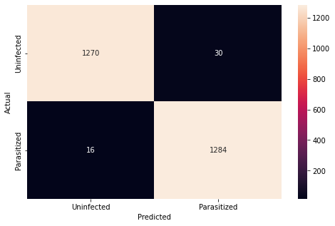

```python
pred1 = model1.predict(test_images)

pred1 = np.argmax(pred1, axis = 1)

y_true = np.argmax(test_labels, axis = 1)

# Printing the classification report
class_rep1 = classification_report(y_true, pred1)

print(class_rep1)

class_rep1 = classification_report(y_true, pred1, output_dict=True)


# Plotting the heatmap using confusion matrix
cm1 = confusion_matrix(y_true, pred1)

plt.figure(figsize = (8, 5))

sns.heatmap(cm1, annot = True,  fmt = '.0f', xticklabels = ['Uninfected', 'Parasitized'], yticklabels = ['Uninfected', 'Parasitized'])

plt.ylabel('Actual')

plt.xlabel('Predicted')

plt.show()
```

**Plotting the train and the validation curves**

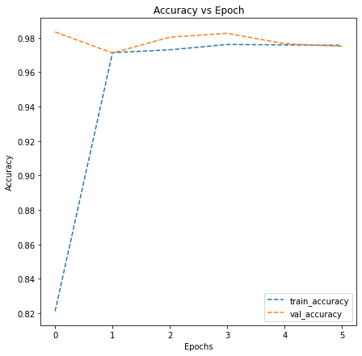

```python
# Function to plot train and validation accuracy

plot_accuracy(history1)
```

### **Think about it:**

Now let's build a model with LeakyRelu as the activation function

- Can the model performance be improved if we change our activation function to LeakyRelu?
- Can BatchNormalization improve our model?

Let us try to build a model using BatchNormalization and using LeakyRelu as our activation function.

### **Model 2 with Batch Normalization**

```python
backend.clear_session() # Clearing the backend for new model
```

### **Building the Model**

```python
from tensorflow.keras.layers import BatchNormalization, LeakyReLU

model2 = Sequential()

model2.add(Conv2D(32, (3, 3), input_shape = (64, 64, 3), padding = 'same')) #first convolutional layer

model2.add(LeakyReLU(0.1))

model2.add(MaxPooling2D(pool_size = 2))

model2.add(Dropout(0.2))

model2.add(Conv2D(32, (3, 3), input_shape = (64, 64, 3), padding = 'same')) #second convolutional layer

model2.add(LeakyReLU(0.1))

model2.add(MaxPooling2D(pool_size = 2))

model2.add(BatchNormalization())

model2.add(Dropout(0.2))

model2.add(Conv2D(32, (3, 3), input_shape = (64, 64, 3), padding = 'same')) #third convolutional layer

model2.add(LeakyReLU(0.1))

model2.add(MaxPooling2D(pool_size = 2))

model2.add(Dropout(0.2))

model2.add(Conv2D(32, (3, 3), input_shape = (64, 64, 3), padding = 'same')) #fourth convolutional layer

model2.add(LeakyReLU(0.1))

model2.add(MaxPooling2D(pool_size = 2))

model2.add(BatchNormalization())

model2.add(Dropout(0.2))

model2.add(Conv2D(32, (3, 3), input_shape = (64, 64, 3), padding = 'same')) #fifth convolutional layer

model2.add(LeakyReLU(0.1))

model2.add(MaxPooling2D(pool_size = 2))

model2.add(Dropout(0.2))

model2.add(Flatten())

model2.add(Dense(512, activation = "relu"))

model2.add(Dropout(0.4))

model2.add(Dense(2, activation = "softmax")) # 2 represents output layer neurons

adam = optimizers.Adam(learning_rate = 0.001)

model2.summary()
```

```
Model: "sequential"
_________________________________________________________________
 Layer (type)                Output Shape              Param #
=================================================================
 conv2d (Conv2D)             (None, 64, 64, 32)        896

 leaky_re_lu (LeakyReLU)     (None, 64, 64, 32)        0

 max_pooling2d (MaxPooling2D  (None, 32, 32, 32)       0
 )

 dropout (Dropout)           (None, 32, 32, 32)        0

 conv2d_1 (Conv2D)           (None, 32, 32, 32)        9248

 leaky_re_lu_1 (LeakyReLU)   (None, 32, 32, 32)        0

 max_pooling2d_1 (MaxPooling  (None, 16, 16, 32)       0
 2D)

 batch_normalization (BatchN  (None, 16, 16, 32)       128
 ormalization)

 dropout_1 (Dropout)         (None, 16, 16, 32)        0

 conv2d_2 (Conv2D)           (None, 16, 16, 32)        9248

 leaky_re_lu_2 (LeakyReLU)   (None, 16, 16, 32)        0

 max_pooling2d_2 (MaxPooling  (None, 8, 8, 32)         0
 2D)

 dropout_2 (Dropout)         (None, 8, 8, 32)          0

 conv2d_3 (Conv2D)           (None, 8, 8, 32)          9248

 leaky_re_lu_3 (LeakyReLU)   (None, 8, 8, 32)          0

 max_pooling2d_3 (MaxPooling  (None, 4, 4, 32)         0
 2D)
```

[output cut: 13 more lines]

```
 dropout_4 (Dropout)         (None, 2, 2, 32)          0

 flatten (Flatten)           (None, 128)               0

 dense (Dense)               (None, 512)               66048

 dropout_5 (Dropout)         (None, 512)               0

 dense_1 (Dense)             (None, 2)                 1026

=================================================================
Total params: 105,218
Trainable params: 105,090
Non-trainable params: 128
_________________________________________________________________
```

### **Compiling the model**

```python
model2.compile(loss = "binary_crossentropy", optimizer = adam, metrics = ['accuracy'])
```

**Using callbacks**

```python
callbacks = [EarlyStopping(monitor = 'val_loss', patience = 2),
             ModelCheckpoint('.mdl_wts.hdf5', monitor = 'val_loss', save_best_only = True)]
```

**Fit and train the model**

```python
history2 = model2.fit(train_images, train_labels, batch_size = 32, callbacks = callbacks, validation_split = 0.2, epochs = 20, verbose = 1)
```

**Plotting the train and validation accuracy**

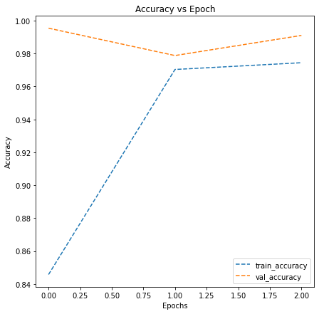

```python
# Plotting the accuracies

plot_accuracy(history2)
```

### **Evaluating the model**

```python
# Evaluate the model to calculate the accuracy

accuracy2 = model2.evaluate(test_images , test_labels, verbose = 1)

print('\n', 'Test_Accuracy:-', accuracy2[1])
```

```
 Test_Accuracy:- 0.9815384745597839
```

**Generate the classification report and confusion matrix**

```
              precision    recall  f1-score   support

           0       0.98      0.99      0.98      1300
           1       0.99      0.98      0.98      1300

    accuracy                           0.98      2600
   macro avg       0.98      0.98      0.98      2600
weighted avg       0.98      0.98      0.98      2600
```

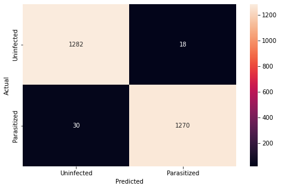

```python
from sklearn.metrics import classification_report

from sklearn.metrics import confusion_matrix

pred2 = model2.predict(test_images)

pred2 = np.argmax(pred2, axis = 1)

y_true = np.argmax(test_labels, axis = 1)

# Printing the classification report
class_rep2 = classification_report(y_true, pred2)

print(class_rep2)

class_rep2 = classification_report(y_true, pred2, output_dict=True)

# Plotting the heatmap using confusion matrix

cm2 = confusion_matrix(y_true, pred2)

plt.figure(figsize = (8, 5))

sns.heatmap(cm2, annot = True,  fmt = '.0f', xticklabels = ['Uninfected', 'Parasitized'], yticklabels = ['Uninfected', 'Parasitized'])

plt.ylabel('Actual')

plt.xlabel('Predicted')

plt.show()
```

### **Think About It :**

- Can we improve the model with Image Data Augmentation?
- References to image data augmentation can be seen below:
  - [Image Augmentation for Computer Vision](https://www.mygreatlearning.com/blog/understanding-data-augmentation/)
  - [How to Configure Image Data Augmentation in Keras?](https://machinelearningmastery.com/how-to-configure-image-data-augmentation-when-training-deep-learning-neural-networks/)

### **Model 3 with Data Augmentation**

```python
backend.clear_session() # Clearing backend for new model
```

### **Using image data generator**

```python
from sklearn.model_selection import train_test_split

X_train, X_val, y_train, y_val = train_test_split(train_images, train_labels, test_size = 0.2, random_state = 42)

from tensorflow.keras.preprocessing.image import ImageDataGenerator

# Using ImageDataGenerator to generate images
train_datagen = ImageDataGenerator(horizontal_flip = True,
                                  zoom_range = 0.5, rotation_range = 30)

val_datagen  = ImageDataGenerator()

# Flowing training images using train_datagen generator
train_generator = train_datagen.flow(x = train_images, y = train_labels, batch_size = 64, seed = 42, shuffle = True)


# Flowing validation images using val_datagen generator
val_generator =  val_datagen.flow(x = test_images, y = test_labels, batch_size = 64, seed = 42, shuffle = True)
```

### **Think About It :**

- Check if the performance of the model can be improved by changing different parameters in the ImageDataGenerator.

#### **Visualizing Augmented images**

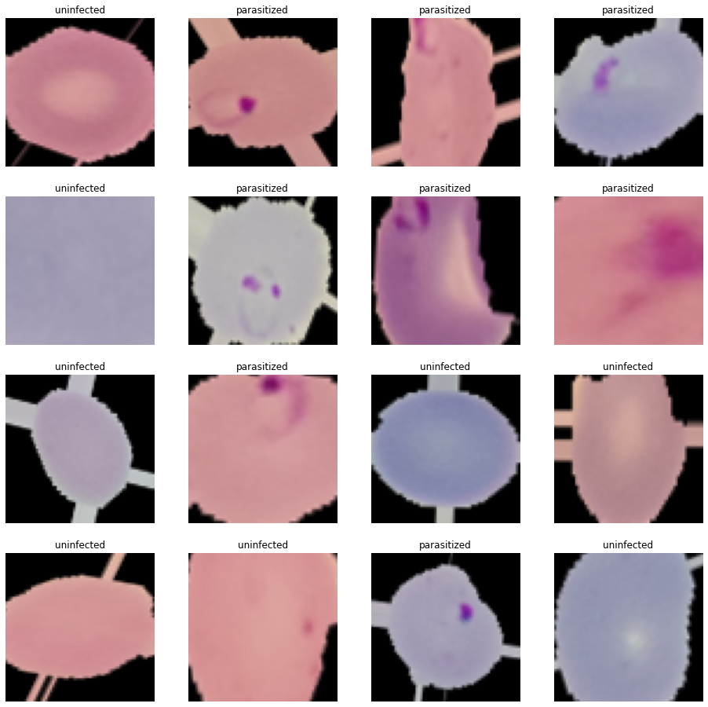

```python
# Creating an iterable for images and labels from the training data
images, labels = next(train_generator)

# Plotting 16 images from the training data
fig, axes = plt.subplots(4, 4, figsize = (16, 8))

fig.set_size_inches(16, 16)
for (image, label, ax) in zip(images, labels, axes.flatten()):

    ax.imshow(image)

    if label[1] == 1:

        ax.set_title('parasitized')

    else:

        ax.set_title('uninfected')

    ax.axis('off')
```

#### **Observations and insights: The sites of the parasites get distorted; either by losing a defined spot boundary or by becoming vague magenta regions.**

### **Building the Model**

```python
model3 = Sequential()

model3.add(Conv2D(32, (3, 3), input_shape = (64, 64, 3), padding = 'same')) #first convolutional layer

model3.add(LeakyReLU(0.1))

model3.add(MaxPooling2D(pool_size = 2))

model3.add(Dropout(0.2))

model3.add(Conv2D(32, (3, 3), input_shape = (64, 64, 3), padding = 'same')) #second convolutional layer

model3.add(LeakyReLU(0.1))

model3.add(MaxPooling2D(pool_size = 2))

model3.add(BatchNormalization())

model3.add(Dropout(0.2))

model3.add(Conv2D(32, (3, 3), input_shape = (64, 64, 3), padding = 'same')) #third convolutional layer

model3.add(LeakyReLU(0.1))

model3.add(MaxPooling2D(pool_size = 2))

model3.add(Dropout(0.2))

model3.add(Conv2D(32, (3, 3), input_shape = (64, 64, 3), padding = 'same')) #fourth convolutional layer

model3.add(LeakyReLU(0.1))

model3.add(MaxPooling2D(pool_size = 2))

model3.add(BatchNormalization())

model3.add(Dropout(0.2))

model3.add(Conv2D(32, (3, 3), input_shape = (64, 64, 3), padding = 'same')) #fifth convolutional layer

model3.add(LeakyReLU(0.1))

model3.add(MaxPooling2D(pool_size = 2))

model3.add(Dropout(0.2))

model3.add(Flatten())

model3.add(Dense(512, activation = "relu"))

model3.add(Dropout(0.4))

model3.add(Dense(2, activation = "softmax")) # 2 represents output layer neurons

adam = optimizers.Adam(learning_rate = 0.001)

model3.compile(loss = 'binary_crossentropy', optimizer = adam, metrics = ['accuracy'])

model3.summary()
```

```
Model: "sequential"
_________________________________________________________________
 Layer (type)                Output Shape              Param #
=================================================================
 conv2d (Conv2D)             (None, 64, 64, 32)        896

 leaky_re_lu (LeakyReLU)     (None, 64, 64, 32)        0

 max_pooling2d (MaxPooling2D  (None, 32, 32, 32)       0
 )

 dropout (Dropout)           (None, 32, 32, 32)        0

 conv2d_1 (Conv2D)           (None, 32, 32, 32)        9248

 leaky_re_lu_1 (LeakyReLU)   (None, 32, 32, 32)        0

 max_pooling2d_1 (MaxPooling  (None, 16, 16, 32)       0
 2D)

 batch_normalization (BatchN  (None, 16, 16, 32)       128
 ormalization)

 dropout_1 (Dropout)         (None, 16, 16, 32)        0

 conv2d_2 (Conv2D)           (None, 16, 16, 32)        9248

 leaky_re_lu_2 (LeakyReLU)   (None, 16, 16, 32)        0

 max_pooling2d_2 (MaxPooling  (None, 8, 8, 32)         0
 2D)

 dropout_2 (Dropout)         (None, 8, 8, 32)          0

 conv2d_3 (Conv2D)           (None, 8, 8, 32)          9248

 leaky_re_lu_3 (LeakyReLU)   (None, 8, 8, 32)          0

 max_pooling2d_3 (MaxPooling  (None, 4, 4, 32)         0
 2D)
```

[output cut: 13 more lines]

```
 dropout_4 (Dropout)         (None, 2, 2, 32)          0

 flatten (Flatten)           (None, 128)               0

 dense (Dense)               (None, 512)               66048

 dropout_5 (Dropout)         (None, 512)               0

 dense_1 (Dense)             (None, 2)                 1026

=================================================================
Total params: 105,218
Trainable params: 105,090
Non-trainable params: 128
_________________________________________________________________
```

**Using Callbacks**

```python
callbacks = [EarlyStopping(monitor = 'val_loss', patience = 2),
             ModelCheckpoint('.mdl_wts.hdf5', monitor = 'val_loss', save_best_only = True)]
```

**Fit and Train the model**

```python
history3 = model3.fit(train_generator,
                                  validation_data = val_generator,
                                  batch_size = 32, callbacks = callbacks,
                                  epochs = 20, verbose = 1)
```

### **Evaluating the model**

**Plot the train and validation accuracy**

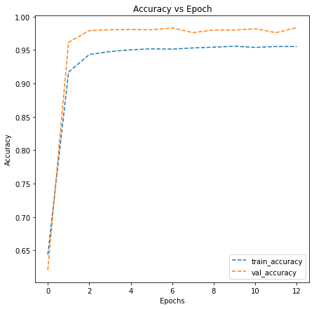

```python
# Plotting the accuracies
plot_accuracy(history3)
```

```python
# Evaluating the model on test data
accuracy3 = model3.evaluate(test_images, test_labels, verbose = 1)

print('\n', 'Test_Accuracy:-', accuracy3[1])
```

```
 Test_Accuracy:- 0.9834615588188171
```

**Plotting the classification report and confusion matrix**

```
              precision    recall  f1-score   support

           0       0.99      0.98      0.98      1300
           1       0.98      0.99      0.98      1300

    accuracy                           0.98      2600
   macro avg       0.98      0.98      0.98      2600
weighted avg       0.98      0.98      0.98      2600
```

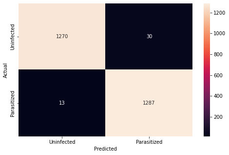

```python
pred3 = model3.predict(test_images)

pred3 = np.argmax(pred3, axis = 1)

y_true = np.argmax(test_labels, axis = 1)

# Printing the classification report
class_rep3 = classification_report(y_true, pred3)

print(class_rep3)

class_rep3 = classification_report(y_true, pred3, output_dict=True)

# Plotting the heatmap using confusion matrix

cm3 = confusion_matrix(y_true, pred3)

plt.figure(figsize = (8, 5))

sns.heatmap(cm3, annot = True,  fmt = '.0f', xticklabels = ['Uninfected', 'Parasitized'], yticklabels = ['Uninfected', 'Parasitized'])

plt.ylabel('Actual')

plt.xlabel('Predicted')

plt.show()
```

**Now, let us try to use a pretrained model like VGG16 and check how it performs on our data.**

### **Pre-trained model (VGG16)**

```python
# Clearing backend
from tensorflow.keras import backend

backend.clear_session()

# Fixing the seed for random number generators
np.random.seed(42)

import random

random.seed(42)

tf.random.set_seed(42)
```

```python
from tensorflow.keras.applications.vgg16 import VGG16

from tensorflow.keras import Model

vgg = VGG16(include_top = False, weights = 'imagenet', input_shape = (64, 64, 3))

vgg.summary()
```

```
Model: "vgg16"
_________________________________________________________________
 Layer (type)                Output Shape              Param #
=================================================================
 input_1 (InputLayer)        [(None, 64, 64, 3)]       0

 block1_conv1 (Conv2D)       (None, 64, 64, 64)        1792

 block1_conv2 (Conv2D)       (None, 64, 64, 64)        36928

 block1_pool (MaxPooling2D)  (None, 32, 32, 64)        0

 block2_conv1 (Conv2D)       (None, 32, 32, 128)       73856

 block2_conv2 (Conv2D)       (None, 32, 32, 128)       147584

 block2_pool (MaxPooling2D)  (None, 16, 16, 128)       0

 block3_conv1 (Conv2D)       (None, 16, 16, 256)       295168

 block3_conv2 (Conv2D)       (None, 16, 16, 256)       590080

 block3_conv3 (Conv2D)       (None, 16, 16, 256)       590080

 block3_pool (MaxPooling2D)  (None, 8, 8, 256)         0

 block4_conv1 (Conv2D)       (None, 8, 8, 512)         1180160

 block4_conv2 (Conv2D)       (None, 8, 8, 512)         2359808

 block4_conv3 (Conv2D)       (None, 8, 8, 512)         2359808

 block4_pool (MaxPooling2D)  (None, 4, 4, 512)         0

 block5_conv1 (Conv2D)       (None, 4, 4, 512)         2359808

 block5_conv2 (Conv2D)       (None, 4, 4, 512)         2359808

 block5_conv3 (Conv2D)       (None, 4, 4, 512)         2359808

 block5_pool (MaxPooling2D)  (None, 2, 2, 512)         0

=================================================================
Total params: 14,714,688
Trainable params: 14,714,688
Non-trainable params: 0
_________________________________________________________________
```

```python
transfer_layer = vgg.get_layer('block5_pool')

vgg.trainable = False

# Add classification layers on top of it
x = Flatten()(transfer_layer.output)  # Flatten the output from the 3rd block of the VGG16 model

x = Dense(256, activation = 'relu')(x)

# Similarly add a dense layer with 128 neurons
x = Dropout(0.3)(x)

# Add a dense layer with 64 neurons
x = BatchNormalization()(x)

pred = Dense(2, activation = 'softmax')(x)

model4 = Model(vgg.input, pred) # Initializing the model
```

### **Compiling the model**

```python
# Compiling the model
adam = optimizers.Adam(learning_rate = 0.001)

model4.compile(loss = 'binary_crossentropy', optimizer = adam, metrics = ['accuracy'])
```

**using callbacks**

```python
# Adding Callbacks to the model
callbacks = [EarlyStopping(monitor = 'val_loss', patience = 2),
             ModelCheckpoint('.mdl_wts.hdf5', monitor = 'val_loss', save_best_only = True)]
```

**Fit and Train the model**

```python
# Fitting the model and running the model for 10 epochs
history4 = model4.fit(
            train_images, train_labels,
            epochs = 20,
            callbacks = callbacks,
            batch_size = 32,
            validation_split = 0.2,
            verbose = 1
)
```

**Plot the train and validation accuracy**

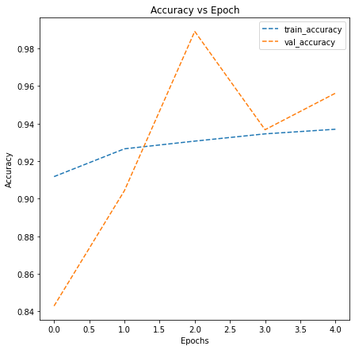

```python
# plotting the accuracies
plot_accuracy(history4)
```

- What can be observed from the validation and train curves?

### **Evaluating the model**

```python
# Evaluating the model on test data

accuracy4 = model4.evaluate(test_images, test_labels, verbose = 1)

print('\n', 'Test_Accuracy:-', accuracy4[1])
```

```
 Test_Accuracy:- 0.9419230818748474
```

**Plotting the classification report and confusion matrix**

```
              precision    recall  f1-score   support

           0       0.96      0.92      0.94      1300
           1       0.92      0.96      0.94      1300

    accuracy                           0.94      2600
   macro avg       0.94      0.94      0.94      2600
weighted avg       0.94      0.94      0.94      2600
```

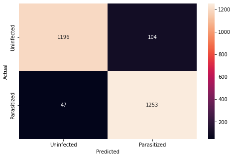

```python
# Plot the confusion matrix and generate a classification report for the model
pred4 = model4.predict(test_images)

pred4 = np.argmax(pred4, axis = 1)

y_true = np.argmax(test_labels, axis = 1)

# Printing the classification report
class_rep4 = classification_report(y_true, pred4)

print(class_rep4)

class_rep4 = classification_report(y_true, pred4, output_dict=True)

# Plotting the heatmap using confusion matrix

cm4 = confusion_matrix(y_true, pred4)

plt.figure(figsize = (8, 5))

sns.heatmap(cm4, annot = True,  fmt = '.0f', xticklabels = ['Uninfected', 'Parasitized'], yticklabels = ['Uninfected', 'Parasitized'])

plt.ylabel('Actual')

plt.xlabel('Predicted')

plt.show()
```

### **Think about it:**

- What observations and insights can be drawn from the confusion matrix and classification report?
- Choose the model with the best accuracy scores from all the above models and save it as a final model.

```python
#generating summary table of accuracies of all the models

#converting classification reports to dataframes to call values

reports=[class_rep,class_rep1,class_rep2, class_rep3, class_rep4]

index=range(len(reports))
dfs=[]
for i in index:
  name= 'df_class_rep' + str(i)
  dfs.append(name)
print('Report names are:',dfs)

collection={}
for i in index:
  df= pd.DataFrame(reports[i]).transpose()
  collection[dfs[i]] = df

print('Collection of Classification Report DataFrames: \n', collection)
```

```
Report names are: ['df_class_rep0', 'df_class_rep1', 'df_class_rep2', 'df_class_rep3', 'df_class_rep4']
Collection of Classification Report DataFrames:
 {'df_class_rep0':               precision    recall  f1-score      support
0              0.983683  0.973846  0.978740  1300.000000
1              0.974105  0.983846  0.978951  1300.000000
accuracy       0.978846  0.978846  0.978846     0.978846
macro avg      0.978894  0.978846  0.978846  2600.000000
weighted avg   0.978894  0.978846  0.978846  2600.000000, 'df_class_rep1':               precision    recall  f1-score      support
0              0.987558  0.976923  0.982212  1300.000000
1              0.977169  0.987692  0.982402  1300.000000
accuracy       0.982308  0.982308  0.982308     0.982308
macro avg      0.982364  0.982308  0.982307  2600.000000
weighted avg   0.982364  0.982308  0.982307  2600.000000, 'df_class_rep2':               precision    recall  f1-score      support
0              0.977134  0.986154  0.981623  1300.000000
1              0.986025  0.976923  0.981453  1300.000000
accuracy       0.981538  0.981538  0.981538     0.981538
macro avg      0.981579  0.981538  0.981538  2600.000000
weighted avg   0.981579  0.981538  0.981538  2600.000000, 'df_class_rep3':               precision    recall  f1-score      support
0              0.989867  0.976923  0.983353  1300.000000
1              0.977221  0.990000  0.983569  1300.000000
accuracy       0.983462  0.983462  0.983462     0.983462
macro avg      0.983544  0.983462  0.983461  2600.000000
weighted avg   0.983544  0.983462  0.983461  2600.000000, 'df_class_rep4':               precision    recall  f1-score      support
0              0.962188  0.920000  0.940621  1300.000000
1              0.923360  0.963846  0.943169  1300.000000
accuracy       0.941923  0.941923  0.941923     0.941923
macro avg      0.942774  0.941923  0.941895  2600.000000
weighted avg   0.942774  0.941923  0.941895  2600.000000}
```

```python
#obtaining values from the confusion matricies

tn, fp, fn, tp = cm.ravel()
tn1, fp1, fn1, tp1 = cm1.ravel()
tn2, fp2, fn2, tp2 = cm2.ravel()
tn3, fp3, fn3, tp3 = cm3.ravel()
tn4, fp4, fn4, tp4 = cm4.ravel()
```

```python
epochs_ex=[len(history.history['loss']),len(history1.history['loss']),len(history2.history['loss']),len(history3.history['loss']),len(history4.history['loss'])]
test_acc= [accuracy[1], accuracy1[1], accuracy2[1], accuracy3[1], accuracy4[1]]
precs=[collection["df_class_rep0"]['precision']['weighted avg'],
       collection["df_class_rep1"]['precision']['weighted avg'],
       collection["df_class_rep2"]['precision']['weighted avg'],
       collection["df_class_rep3"]['precision']['weighted avg'],
       collection["df_class_rep4"]['precision']['weighted avg']]
recalls=[collection["df_class_rep0"]['recall']['weighted avg'],
       collection["df_class_rep1"]['recall']['weighted avg'],
       collection["df_class_rep2"]['recall']['weighted avg'],
       collection["df_class_rep3"]['recall']['weighted avg'],
       collection["df_class_rep4"]['recall']['weighted avg']]
f1scores=[collection["df_class_rep0"]['f1-score']['weighted avg'],
       collection["df_class_rep1"]['f1-score']['weighted avg'],
       collection["df_class_rep2"]['f1-score']['weighted avg'],
       collection["df_class_rep3"]['f1-score']['weighted avg'],
       collection["df_class_rep4"]['f1-score']['weighted avg']]
falsepos=[fp, fp1, fp2, fp3, fp4]
falsenegs=[fn,fn1,fn2,fn3,fn4]
headers=['Model Base','Model 1', 'Model 2', 'Model 3', 'Model 4 ']
indicies=['Epochs Executed', 'Test Accuracy', 'Precision', 'Recall', 'F1-Score', 'False Positives', 'False Negatives']

lists=[epochs_ex,test_acc,precs,recalls,f1scores,falsepos,falsenegs]
df = pd.concat([pd.Series(x) for x in lists], axis=1)
df=df.T
df.columns = headers
df.index = indicies
print(df)
```

```
                 Model Base    Model 1    Model 2    Model 3    Model 4
Epochs Executed    9.000000   6.000000   3.000000  13.000000    5.000000
Test Accuracy      0.978846   0.982308   0.981538   0.983462    0.941923
Precision          0.978894   0.982364   0.981579   0.983544    0.942774
Recall             0.978846   0.982308   0.981538   0.983462    0.941923
F1-Score           0.978846   0.982307   0.981538   0.983461    0.941895
False Positives   34.000000  30.000000  18.000000  30.000000  104.000000
False Negatives   21.000000  16.000000  30.000000  13.000000   47.000000
```

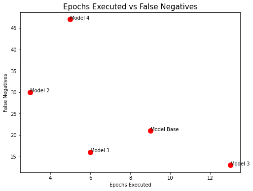

```python
plt.figure(figsize=(8,6))
plt.scatter(epochs_ex,falsenegs,s=100,color="red")
plt.xlabel("Epochs Executed")
plt.ylabel("False Negatives")
plt.title("Epochs Executed vs False Negatives",fontsize=15)
for i, label in enumerate(headers):
    plt.annotate(label, (epochs_ex[i], falsenegs[i]))

plt.show()
```

**Improvements that can be done:**

- Can the model performance be improved using other pre-trained models or different CNN architecture?
- You can try to build a model using these HSV images and compare them with your other models.

```python
model.save("/content/drive/MyDrive/Capstone_Project/model.h5")
model1.save("/content/drive/MyDrive/Capstone_Project/model1.h5")
model2.save("/content/drive/MyDrive/Capstone_Project/model2.h5")
model3.save("/content/drive/MyDrive/Capstone_Project/model3.h5")
model4.save("/content/drive/MyDrive/Capstone_Project/model4.h5")
```

#### **Refined insights**:

- What are the most meaningful insights from the data relevant to the problem?

In order to build the most optimized deep learning model to detect malaria, several models were explored: Model Base Model 1 Extra Layers  
Model 2 LeakyReLU  
Model 3 Data Augmentation  
Model 4 VGG16

Model Base This model consisted of 3 convolutional layers with ReLU activation with max pooling and dropout layers after each It also included a flatten layer and a dense layer with ReLU activation before the output layer It yielded a fairly high test accuracy. From the Accuracy vs Epoch graph the training and validation accuracy are increasing with the validation slightly higher than the train

Model 1 Extra Layers This model extended the base model with the addition of consisted of 2 convolutional layers with ReLU activation with max pooling and dropout layers after each It also yielded a high test accuracy Epochs were executed on par to the base model indicating a similar level of fitting to the training data as the base model From the Accuracy vs Epoch graph the training accuracy rises and stays whereas the validation accuracy fluctuates around that area

Model 2 Leaky ReLU This model extended the model 1 with the conversion of all 5 ReLU activations to LeakyReLU and BatchNormalization layers It yielded a similar test accuracy as the previous models Fewer epochs were executed indicating shorter optimization to validation accuracy From the Accuracy vs Epoch graph the training accuracy starts much lower and validation accuracy starts higher and they meet at high accuracy.

Model 3 Data Augmentation This model utilized the same neural network as Model 2 with data augmentation (horizontal flip, 0.5 zoom and 30 deg rotation) applied to the train set It also yielded a similar test accuracy More Epochs were executed due to the augmentation between the train and validation image sets The Accuracy vs Epoch graph show the training and validation accuracy are increasing in synchronous manner with the validation ending up slightly higher indicating this model performs better on the regular images despite being trained on the augmented ones.

#### **Comparison of various techniques and their relative performance**:

- How do different techniques perform? Which one is performing relatively better? Is there scope to improve the performance further?

Referencing Table in Line 146:

From the table on the previous slide it is clear that the main difference between the performance of each of the models is the number of epochs executed and the false negatives and false positives. Although the classification report parameters measure this, the size of the sets make it difficult to see the difference via percents. All the models have high test accuracy, precision, recall and F1-score Between false positives and false negatives the latter is far more important as it tells the patient they do not have malaria when they really do, rather than a false positives where the individual can take the test again to make sure they are uninfected Models with higher epochs mean that they have more passes through the neural networks before the validation accuracy begins to decrease ie. it takes more passes before the early stopping indicates that the model is overfitting the training data

Refencing Graph in Line 150:

From this graph we are able to quickly see the correlation between epochs executed before early stopping was applied and the false negatives obtained from the output of the model. It is also clear that Model 3 shows the best overall performance on the test data set To improve the performance further I would take Model 3 and apply HSV pre-processing to the images to allow for a greater ability to recognize the changes in the colours of the parasitized and uninfected cells

#### **Proposal for the final solution design**:

- What model do you propose to be adopted? Why is this the best solution to adopt?

As such the best solution to adopt is Model 3 Data Augmentation Model 3 combines the best features of the previously tried models that enhanced accuracy: multiple layers, Leaky ReLU, batch normalization, and dropout It also integrates the implementation of flip, zoom and rotation on the train images which increases the accuracy on both the validation set and the test set due to the removal of overfitting to the set of train images. For the final model, Model 3 will be run with HSV to enhance the image colours and as a result optimize classification.

# **Malaria Detection HSV and Model 3**

### **Mounting the Drive**

```python
# Mounting the drive
from google.colab import drive

drive.mount('/content/drive')
```

### **Loading libraries**

```python
# Importing libraries required to load the data
import zipfile

import os

from PIL import Image

import numpy as np

import pandas as pd

import matplotlib.pyplot as plt

import seaborn as sns

from sklearn.model_selection import train_test_split

from sklearn.preprocessing import MinMaxScaler


import tensorflow as tf

from tensorflow.keras import optimizers

from tensorflow.keras.utils import to_categorical


# To ignore warnings
import warnings

warnings.filterwarnings('ignore')

# Remove the limit from the number of displayed columns and rows. It helps to see the entire dataframe while printing it
pd.set_option("display.max_columns", None)

pd.set_option("display.max_rows", 200)
```

### **Let us load the data**

```python
# Storing the path of the data file from the Google drive
path = '/content/drive/MyDrive/Capstone_Project/cell_images.zip'

# The data is provided as a zip file so we need to extract the files from the zip file
with zipfile.ZipFile(path, 'r') as zip_ref:

    zip_ref.extractall()
```

The extracted folder has different folders for train and test data which further contains the different sizes of images for parasitized and uninfected cells within the respective folder name.

The size of all images must be the same and should be converted to 4D arrays so that they can be used as an input for the convolutional neural network. Also, we need to create the labels for both types of images to be able to train and test the model.

Let's do the same for the training data first and then we will use the same code for the test data as well.

```python
# Storing the path of the extracted "train" folder
train_dir = '/content/cell_images/train'

# Size of image so that each image has the same size
SIZE = 64

# Empty list to store the training images after they are converted to NumPy arrays
train_images = []

# Empty list to store the training labels (0 - uninfected, 1 - parasitized)
train_labels = []
```

```python
# We will run the same code for "parasitized" as well as "uninfected" folders within the "train" folder
for folder_name in ['/parasitized/', '/uninfected/']:

    # Path of the folder
    images_path = os.listdir(train_dir + folder_name)

    for i, image_name in enumerate(images_path):

        try:

            # Opening each image using the path of that image
            image = Image.open(train_dir + folder_name + image_name)

            # Resizing each image to (64, 64)
            image = image.resize((SIZE, SIZE))

            # Converting images to arrays and appending that array to the empty list defined above
            train_images.append(np.array(image))

            # Creating labels for parasitized and uninfected images
            if folder_name == '/parasitized/':

                train_labels.append(1)

            else:

                train_labels.append(0)

        except Exception:

            pass

# Converting lists to arrays
train_images = np.array(train_images)

train_labels = np.array(train_labels)
```

```python
# Storing the path of the extracted "test" folder
test_dir = '/content/cell_images/test'

# Size of image so that each image has the same size (it must be same as the train image size)
SIZE = 64

# Empty list to store the testing images after they are converted to NumPy arrays
test_images = []

# Empty list to store the testing labels (0 - uninfected, 1 - parasitized)
test_labels = []
```

```python
# We will run the same code for "parasitized" as well as "uninfected" folders within the "test" folder
for folder_name in ['/parasitized/', '/uninfected/']:

    # Path of the folder
    images_path = os.listdir(test_dir + folder_name)

    for i, image_name in enumerate(images_path):

        try:
            # Opening each image using the path of that image
            image = Image.open(test_dir + folder_name + image_name)

            # Resizing each image to (64, 64)
            image = image.resize((SIZE, SIZE))

            # Converting images to arrays and appending that array to the empty list defined above
            test_images.append(np.array(image))

            # Creating labels for parasitized and uninfected images
            if folder_name == '/parasitized/':

                test_labels.append(1)

            else:

                test_labels.append(0)

        except Exception:

            pass

# Converting lists to arrays
test_images = np.array(test_images)

test_labels = np.array(test_labels)
```

### **Normalize the images**

```python
# Try to normalize the train and test images by dividing it by 255 and convert them to float32 using astype function
train_images = (train_images/255).astype('float32')

test_images = (test_images/255).astype('float32')
```

As we have done our preprocessing required and performed some EDA to gain some insights in our Milestone-1 so now we will try to build our model and try evaluating its performance.

### **Converting RGB to HSV of Images using OpenCV**

```python
import cv2

gfx=[]   # to hold the HSV image array

for i in np.arange(0, 24958, 1):

  a = cv2.cvtColor(train_images[i], cv2.COLOR_BGR2HSV)

  gfx.append(a)

gfx = np.array(gfx)
```

```python
gft=[]   # to hold the HSV image array

for i in np.arange(0, 2600, 1):

  a = cv2.cvtColor(test_images[i], cv2.COLOR_BGR2HSV)

  gft.append(a)

gft = np.array(gft)
```

### **Converting the train data**

[output not shown]

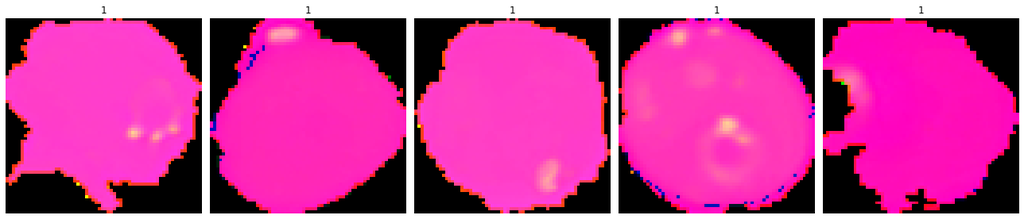

```python
viewimage = np.random.randint(1, 24958, 5)

fig, ax = plt.subplots(1, 5, figsize = (18, 18))

for t, i in zip(range(5), viewimage):

  Title = train_labels[i]

  ax[t].set_title(Title)

  ax[t].imshow(gfx[i])

  ax[t].set_axis_off()

  fig.tight_layout()
```

### **Converting the test data**

[output not shown]

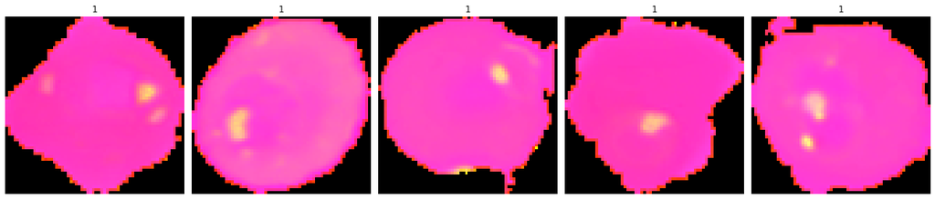

```python
# Similarly you can visualize for the images in the test data
viewimage = np.random.randint(1, 100, 5)

fig, ax = plt.subplots(1, 5, figsize = (18, 18))

for t, i in zip(range(5), viewimage):

  Title = test_labels[i]

  ax[t].set_title(Title)

  ax[t].imshow(gft[i])

  ax[t].set_axis_off()

  fig.tight_layout()
```

### **Model 5 with Data Augmentation and HSV**

### **One Hot Encoding on the train and test labels**

```python
# Encoding Train Labels

train_labels = to_categorical(train_labels, 2)

# Similarly let us try to encode test labels
test_labels = to_categorical(test_labels, 2)
```

### **Importing the required libraries for building and training our Model**

```python
# Clearing backend
from tensorflow.keras import backend

from tensorflow.keras.utils import to_categorical

from tensorflow.keras.models import Sequential

from tensorflow.keras.layers import Conv2D, MaxPooling2D, Dense, Flatten, Dropout

from tensorflow.keras.callbacks import EarlyStopping, ModelCheckpoint

from random import shuffle

backend.clear_session()

# Fixing the seed for random number generators so that we can ensure we receive the same output everytime
np.random.seed(42)

import random

random.seed(42)

tf.random.set_seed(42)
```

### **Using image data generator**

```python
from sklearn.model_selection import train_test_split

X_train, X_val, y_train, y_val = train_test_split(gfx, train_labels, test_size = 0.2, random_state = 42)

from tensorflow.keras.preprocessing.image import ImageDataGenerator

# Using ImageDataGenerator to generate images
train_datagen = ImageDataGenerator(horizontal_flip = True,
                                  zoom_range = 0.5, rotation_range = 30)

val_datagen  = ImageDataGenerator()

# Flowing training images using train_datagen generator
train_generator = train_datagen.flow(x = gfx, y = train_labels, batch_size = 64, seed = 42, shuffle = True)


# Flowing validation images using val_datagen generator
val_generator =  val_datagen.flow(x = gft, y = test_labels, batch_size = 64, seed = 42, shuffle = True)
```

### **Think About It :**

- Check if the performance of the model can be improved by changing different parameters in the ImageDataGenerator.

#### **Visualizing Augmented images**

[output not shown]

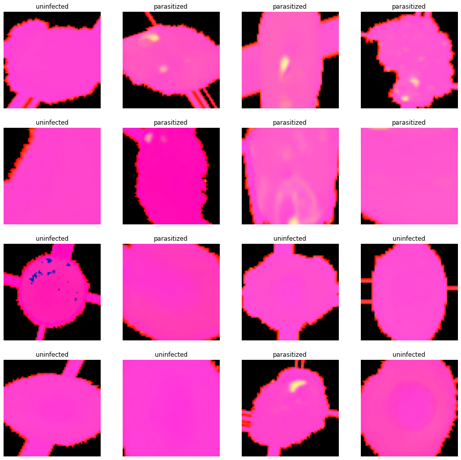

```python
# Creating an iterable for images and labels from the training data
images, labels = next(train_generator)

# Plotting 16 images from the training data
fig, axes = plt.subplots(4, 4, figsize = (16, 8))

fig.set_size_inches(16, 16)
for (image, label, ax) in zip(images, labels, axes.flatten()):

    ax.imshow(image)

    if label[1] == 1:

        ax.set_title('parasitized')

    else:

        ax.set_title('uninfected')

    ax.axis('off')
```

#### **Observations and insights: The sites of the parasites get distorted; either by losing a defined spot boundary or by becoming vague yellow regions.**

### **Building the Final Model**

```python
from tensorflow.keras.layers import BatchNormalization, LeakyReLU

model5 = Sequential()

model5.add(Conv2D(32, (3, 3), input_shape = (64, 64, 3), padding = 'same')) #first convolutional layer

model5.add(LeakyReLU(0.1))

model5.add(MaxPooling2D(pool_size = 2))

model5.add(Dropout(0.2))

model5.add(Conv2D(32, (3, 3), input_shape = (64, 64, 3), padding = 'same')) #second convolutional layer

model5.add(LeakyReLU(0.1))

model5.add(MaxPooling2D(pool_size = 2))

model5.add(BatchNormalization())

model5.add(Dropout(0.2))

model5.add(Conv2D(32, (3, 3), input_shape = (64, 64, 3), padding = 'same')) #third convolutional layer

model5.add(LeakyReLU(0.1))

model5.add(MaxPooling2D(pool_size = 2))

model5.add(Dropout(0.2))

model5.add(Conv2D(32, (3, 3), input_shape = (64, 64, 3), padding = 'same')) #fourth convolutional layer

model5.add(LeakyReLU(0.1))

model5.add(MaxPooling2D(pool_size = 2))

model5.add(BatchNormalization())

model5.add(Dropout(0.2))

model5.add(Conv2D(32, (3, 3), input_shape = (64, 64, 3), padding = 'same')) #fifth convolutional layer

model5.add(LeakyReLU(0.1))

model5.add(MaxPooling2D(pool_size = 2))

model5.add(Dropout(0.2))

model5.add(Flatten())

model5.add(Dense(512, activation = "relu"))

model5.add(Dropout(0.4))

model5.add(Dense(2, activation = "softmax")) # 2 represents output layer neurons

adam = optimizers.Adam(learning_rate = 0.001)

model5.compile(loss = 'binary_crossentropy', optimizer = adam, metrics = ['accuracy'])

model5.summary()
```

```
Model: "sequential"
_________________________________________________________________
 Layer (type)                Output Shape              Param #
=================================================================
 conv2d (Conv2D)             (None, 64, 64, 32)        896

 leaky_re_lu (LeakyReLU)     (None, 64, 64, 32)        0

 max_pooling2d (MaxPooling2D  (None, 32, 32, 32)       0
 )

 dropout (Dropout)           (None, 32, 32, 32)        0

 conv2d_1 (Conv2D)           (None, 32, 32, 32)        9248

 leaky_re_lu_1 (LeakyReLU)   (None, 32, 32, 32)        0

 max_pooling2d_1 (MaxPooling  (None, 16, 16, 32)       0
 2D)

 batch_normalization (BatchN  (None, 16, 16, 32)       128
 ormalization)

 dropout_1 (Dropout)         (None, 16, 16, 32)        0

 conv2d_2 (Conv2D)           (None, 16, 16, 32)        9248

 leaky_re_lu_2 (LeakyReLU)   (None, 16, 16, 32)        0

 max_pooling2d_2 (MaxPooling  (None, 8, 8, 32)         0
 2D)

 dropout_2 (Dropout)         (None, 8, 8, 32)          0

 conv2d_3 (Conv2D)           (None, 8, 8, 32)          9248

 leaky_re_lu_3 (LeakyReLU)   (None, 8, 8, 32)          0

 max_pooling2d_3 (MaxPooling  (None, 4, 4, 32)         0
 2D)
```

[output cut: 13 more lines]

```
 dropout_4 (Dropout)         (None, 2, 2, 32)          0

 flatten (Flatten)           (None, 128)               0

 dense (Dense)               (None, 512)               66048

 dropout_5 (Dropout)         (None, 512)               0

 dense_1 (Dense)             (None, 2)                 1026

=================================================================
Total params: 105,218
Trainable params: 105,090
Non-trainable params: 128
_________________________________________________________________
```

**Using Callbacks**

```python
callbacks = [EarlyStopping(monitor = 'val_loss', patience = 2),
             ModelCheckpoint('.mdl_wts.hdf5', monitor = 'val_loss', save_best_only = True)]
```

**Fit and Train the model**

```python
history5 = model5.fit(train_generator,
                                  validation_data = val_generator,
                                  batch_size = 32, callbacks = callbacks,
                                  epochs = 20, verbose = 1)
```

### **Evaluating the model**

**Plot the train and validation accuracy**

```python
# Function to plot train and validation accuracy
def plot_accuracy(history):

    N = len(history.history["accuracy"])

    plt.figure(figsize = (7, 7))

    plt.plot(np.arange(0, N), history.history["accuracy"], label = "train_accuracy", ls = '--')

    plt.plot(np.arange(0, N), history.history["val_accuracy"], label = "val_accuracy", ls = '--')

    plt.title("Accuracy vs Epoch")

    plt.xlabel("Epochs")

    plt.ylabel("Accuracy")

    plt.legend(loc="bottom right")
```

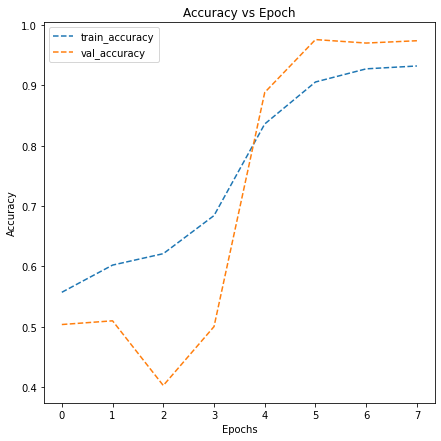

```python
# Plotting the accuracies
plot_accuracy(history5)
```

```python
# Evaluating the model on test data
accuracy5 = model5.evaluate(gft, test_labels, verbose = 1)

print('\n', 'Test_Accuracy:-', accuracy5[1])
```

```
 Test_Accuracy:- 0.9742307662963867
```

**Plotting the classification report and confusion matrix**

```
              precision    recall  f1-score   support

           0       0.96      0.99      0.97      1300
           1       0.99      0.96      0.97      1300

    accuracy                           0.97      2600
   macro avg       0.97      0.97      0.97      2600
weighted avg       0.97      0.97      0.97      2600
```

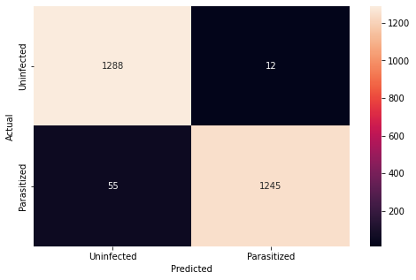

```python
from sklearn.metrics import classification_report

from sklearn.metrics import confusion_matrix

pred5 = model5.predict(gft)

pred5 = np.argmax(pred5, axis = 1)

y_true = np.argmax(test_labels, axis = 1)

# Printing the classification report
class_rep5 = classification_report(y_true, pred5)

print(class_rep5)

class_rep5 = classification_report(y_true, pred5, output_dict=True)

# Plotting the heatmap using confusion matrix

cm5 = confusion_matrix(y_true, pred5)

plt.figure(figsize = (8, 5))

sns.heatmap(cm5, annot = True,  fmt = '.0f', xticklabels = ['Uninfected', 'Parasitized'], yticklabels = ['Uninfected', 'Parasitized'])

plt.ylabel('Actual')

plt.xlabel('Predicted')

plt.show()
```

### **Think about it:**

- What observations and insights can be drawn from the confusion matrix and classification report?
- Choose the model with the best accuracy scores from all the above models and save it as a final model.

#### **Observations and Conclusions drawn from the final model: We can see from the confusion matrix that the false negatives is much higher than most of the models. This indicates to us that although as humans we might be able to distinguish 2 bright colours more effectively, this model prefers to distinguish between the dark magenta and the light pink/lavender background in the original cell images.**

```python
model5.save("/content/drive/MyDrive/Capstone_Project/model5.h5")
```

```python
model = tf.keras.models.load_model('/content/drive/MyDrive/Capstone_Project/model3.h5')
converter = tf.lite.TFLiteConverter.from_keras_model(model)
tflmodel = converter.convert()
file = open( '/content/drive/MyDrive/Capstone_Project/finalmalariamodel3.tflite' , 'wb' )
file.write( tflmodel )
```

```
427576
```

```python
#appending model 5 stats to model performance table

tn5, fp5, fn5, tp5 = cm5.ravel()


m5=[len(history5.history['loss']),accuracy5[1],class_rep5['weighted avg']['precision'],class_rep5['weighted avg']['recall'],class_rep5['weighted avg']['f1-score'], fp5, fn5]
```

```python
df = pd.read_csv('/content/drive/MyDrive/Capstone_Project/model_performance_MS2.csv')
```

```python
df.head()
```

|  |  | Model Base | Model 1 | Model 2 | Model 3 | Model 4 | Unnamed: 6 |
| --- | --- | --- | --- | --- | --- | --- | --- |
| 0 | Epochs Executed | 9.0000 | 6.0000 | 3.0000 | 13.0000 | 5.0000 | NaN |
| 1 | Test Accuracy | 0.9788 | 0.9823 | 0.9815 | 0.9835 | 0.9419 | NaN |
| 2 | Precision | 0.9789 | 0.9824 | 0.9816 | 0.9835 | 0.9428 | NaN |
| 3 | Recall | 0.9788 | 0.9823 | 0.9815 | 0.9835 | 0.9419 | NaN |
| 4 | F1-Score | 0.9788 | 0.9823 | 0.9815 | 0.9835 | 0.9419 | NaN |

```python
del df['Unnamed: 6']
```

```python
df=df.assign(Model5=m5)
```

```python
df.to_csv('/content/drive/MyDrive/Capstone_Project/app_model_performance_MS2.csv')
```

```python
df = pd.read_csv('/content/drive/MyDrive/Capstone_Project/app_model_performance_MS2.csv')
```

```python
epochs=df.loc[0].values.tolist()
del epochs[0:2]

FN=df.loc[6].values.tolist()
del FN[0:2]
```

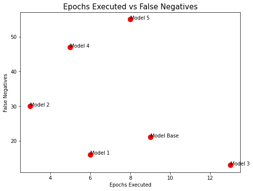

```python
headers=['Model Base','Model 1', 'Model 2', 'Model 3', 'Model 4 ', 'Model 5']


plt.figure(figsize=(8,6))
plt.scatter(epochs,FN,s=100,color="red")
plt.xlabel("Epochs Executed")
plt.ylabel("False Negatives")
plt.title("Epochs Executed vs False Negatives",fontsize=15)
for i, label in enumerate(headers):
    plt.annotate(label, (epochs[i], FN[i]))

plt.show()
```